# Assignment 1 - STK 353

## Question 2: Use the Urn model to determine if the Calcium treatment is effective or not

Our aim is to investigate the effectivesness of the Calcium treatment

### 2b) Sample 50,000 trials from the Urn model and show a histogram of the results.

```r
#Define the Urn
urnC = c(7,-4,18,17,-3,-5,1,10,11,-2,-1,12,-1,-3,3,-5,5,2,-11,-1,-3)

#Simulate 50,000 trials
trialsC = replicate(50000,mean(sample(urnC,10,replace=FALSE)))

#Summarize the data
mean(trialsC) #for Question 2d)
```

```
## [1] 2.22756
```

```r
sd(trialsC) #for Question 2d)
```

```
## [1] 1.755517
```

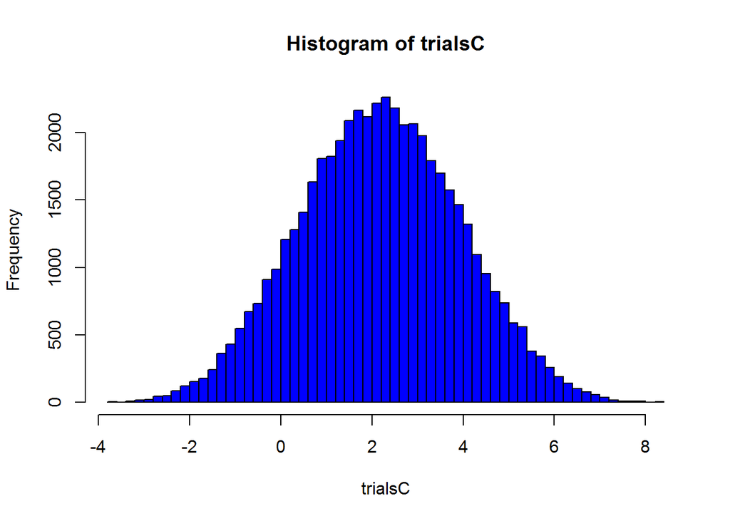

```r
hist(trialsC,breaks=50,col="Blue")
```

```r
# the number of standard deviations that 0 is away from the mean:
(mean(trialsC)-0)/sd(trialsC)
```

```
## [1] 1.268891
```

### 2c) Discuss your method to test whether the treatment is effective or not.

We use the Central Limit Theorem to test the hypothesis that the changes in blood pressure were unaffected by Calcium treatments. Using 50,000 trials, we derive an empirical estimate to the true distribution of the changes in blood pressure and we compare this to a Normal distribution with mean zero (since unaffected blood pressures are expected to remain the same, on average).

### 2d) Do you think the Calcium treatment is effective? Motivate your answer.

Following the method described in Question 2c) we note that it seems likely that the changes in blood pressure were unaffected by the Calcium treatment - if there were no effects from the treatment, the mean would have been close to zero, but note that zero is only around 1.27 standard deviations away from the mean. This is not significant enough to make confident conclusions. More data points (treated and untreated people’s blood pressures) need to be gathered to investigate further.